# curatedTCGAManu

## Multi-omic integration of public oncology databases in Bioconductor

This repository contains scripts and datasets for the curatedTCGAData + cBioPortalData manuscript.

## Overview

We provide several examples to demonstrate the powerful and flexible analysis environment provided. These analyses, previously only achievable through a significant investment of time and bioinformatic training, become straight- forward analysis exercises provided as vignettes.

## Key Points

- Key objective: To provide flexible, integrated multi-omic representations of public oncology databases in R/Bioconductor with grealy reduced data management overhead.
- Knowledge generated: Our Bioconductor software packages provide a novel approach to lower barriers to analysis and tool development for the TCGA and cBioPortal databases.
- Relevance: Our tools provide flexible, programmatic analysis of hundreds of fully integrated multi’omic oncology datasets within an ecosystem of multi-omic analysis tools.

## Key Packages

- [MultiAssayExperiment](http://waldronlab.io/MultiAssayExperiment/index.html)
- curatedTCGAData
- TCGAutils
- cBioPortalData
- EnrichmentBrowser
- GSEABenchmarkeR
- RTCGAToolbox

## Installation

Until the release of Bioconductor 3.11 (scheduled for April 28, 2020), it is strongly recommended to use the *devel* version of Bioconductor. That version can be installed the [traditional way](https://bioconductor.org/developers/how-to/useDevel/) or by using the [Docker container](https://bioconductor.org/help/docker/).

Additionally until the release of Bioconductor 3.11, `cBioPortalData` must be installed from GitHub as shown in the following code chunk which installs all necessary packages either directly or as dependencies. Note that this code chunk is not evaluated, because installation only needs to be performed once.

```r
BiocManager::install(c("waldronlab/cBioPortalData", "LiNk-NY/curatedTCGAManu"))
```

## Vignette Build

Because of the size of the data, it is recommended that the vignettes be built individually. If using RStudio, the user can simply open the vignette and press the `knit` button. Otherwise, the package can be built completely with vignettes by doing:

```
    R CMD build curatedTCGAManu
```

in the command line or

```r
BiocManager::install("Link-NY/curatedTCGAManu", build_vignettes = TRUE)
```

in R.

## Loading packages

```r
library(curatedTCGAData)
library(cBioPortalData)
library(TCGAutils)
library(GenomicDataCommons)
library(rtracklayer)
```

*Note*. For clarity, we include `library` commands within the supplemental code chunks.

# Figures

## Figure 1

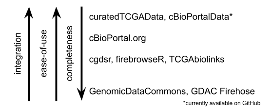

### Example Multi-omic Analyses

# Supplement Reference

## Figure S1

[figure not shown]

## Figure S2A

### Example code for installing and downloading TCGA data using curatedTCGAData.

```r
if (!requireNamespace("BiocManager", quietly = TRUE))
    install.packages("BiocManager")

# BiocManager::install("curatedTCGAData")

library(curatedTCGAData)

## Glioblastoma Multiforme (GBM)

curatedTCGAData(diseaseCode = "GBM", assays = "*", dry.run = FALSE)
```

```
#> A MultiAssayExperiment object of 18 listed
#>  experiments with user-defined names and respective classes.
#>  Containing an ExperimentList class object of length 18:
#>  [1] GBM_CNACGH_CGH_hg_244a-20160128: RaggedExperiment with 81512 rows and 438 columns
#>  [2] GBM_CNACGH_CGH_hg_415k_g4124a-20160128: RaggedExperiment with 57975 rows and 338 columns
#>  [3] GBM_CNASNP-20160128: RaggedExperiment with 602338 rows and 1104 columns
#>  [4] GBM_CNVSNP-20160128: RaggedExperiment with 146852 rows and 1104 columns
#>  [5] GBM_GISTIC_AllByGene-20160128: SummarizedExperiment with 24776 rows and 577 columns
#>  [6] GBM_GISTIC_ThresholdedByGene-20160128: SummarizedExperiment with 24776 rows and 577 columns
#>  [7] GBM_miRNAArray-20160128: SummarizedExperiment with 534 rows and 565 columns
#>  [8] GBM_miRNASeqGene-20160128: SummarizedExperiment with 1046 rows and 0 columns
#>  [9] GBM_mRNAArray_huex-20160128: SummarizedExperiment with 18632 rows and 431 columns
#>  [10] GBM_mRNAArray_TX_g4502a_1-20160128: SummarizedExperiment with 17814 rows and 401 columns
#>  [11] GBM_mRNAArray_TX_g4502a-20160128: SummarizedExperiment with 17814 rows and 101 columns
#>  [12] GBM_mRNAArray_TX_ht_hg_u133a-20160128: SummarizedExperiment with 12042 rows and 528 columns
#>  [13] GBM_Mutation-20160128: RaggedExperiment with 22073 rows and 290 columns
#>  [14] GBM_RNASeq2GeneNorm-20160128: SummarizedExperiment with 20501 rows and 166 columns
#>  [15] GBM_RPPAArray-20160128: SummarizedExperiment with 208 rows and 244 columns
#>  [16] GBM_GISTIC_Peaks-20160128: RangedSummarizedExperiment with 68 rows and 577 columns
#>  [17] GBM_Methylation_methyl27-20160128: SummarizedExperiment with 27578 rows and 285 columns
#>  [18] GBM_Methylation_methyl450-20160128: SummarizedExperiment with 485577 rows and 154 columns
#> Features:
#>  experiments() - obtain the ExperimentList instance
#>  colData() - the primary/phenotype DataFrame
#>  sampleMap() - the sample availability DFrame
#>  `$`, `[`, `[[` - extract colData columns, subset, or experiment
#>  *Format() - convert into a long or wide DataFrame
#>  assays() - convert ExperimentList to a SimpleList of matrices
```

## Figure S2B

### Example cBioPortalData code for downloading TCGA data from cBioPortal.org and via the cBioPortal API

```r
## installation
# BiocManager::install("WaldronLab/cBioPortalData")

library(cBioPortalData)

## https://cbioportal.org/datasets (Bulk data method)
gbm <- cBioDataPack("gbm_tcga")

## https://cBioPortal.org/api (API method)
cBio <- cBioPortal()
cBioPortalData(cBio, studyId = "gbm_tcga", genePanelId = "IMPACT341")
```

```
#> A MultiAssayExperiment object of 13 listed
#>  experiments with user-defined names and respective classes.
#>  Containing an ExperimentList class object of length 13:
#>  [1] gbm_tcga_rppa: SummarizedExperiment with 67 rows and 244 columns
#>  [2] gbm_tcga_rppa_Zscores: SummarizedExperiment with 67 rows and 244 columns
#>  [3] gbm_tcga_gistic: SummarizedExperiment with 339 rows and 577 columns
#>  [4] gbm_tcga_mrna_U133: SummarizedExperiment with 311 rows and 528 columns
#>  [5] gbm_tcga_mrna_U133_Zscores: SummarizedExperiment with 308 rows and 528 columns
#>  [6] gbm_tcga_mrna: SummarizedExperiment with 334 rows and 401 columns
#>  [7] gbm_tcga_mrna_median_Zscores: SummarizedExperiment with 329 rows and 401 columns
#>  [8] gbm_tcga_rna_seq_v2_mrna: SummarizedExperiment with 341 rows and 166 columns
#>  [9] gbm_tcga_rna_seq_v2_mrna_median_Zscores: SummarizedExperiment with 333 rows and 166 columns
#>  [10] gbm_tcga_linear_CNA: SummarizedExperiment with 339 rows and 577 columns
#>  [11] gbm_tcga_methylation_hm27: SummarizedExperiment with 282 rows and 285 columns
#>  [12] gbm_tcga_methylation_hm450: SummarizedExperiment with 282 rows and 153 columns
#>  [13] gbm_tcga_mutations: RangedSummarizedExperiment with 810 rows and 271 columns
#> Features:
#>  experiments() - obtain the ExperimentList instance
#>  colData() - the primary/phenotype DFrame
#>  sampleMap() - the sample availability DFrame
#>  `$`, `[`, `[[` - extract colData columns, subset, or experiment
#>  *Format() - convert into a long or wide DFrame
#>  assays() - convert ExperimentList to a SimpleList of matrices
```

## Figure S2C

### Example hg19 to hg38 liftover procedure using Bioconductor tools

```r
liftchain <- "http://hgdownload.cse.ucsc.edu/goldenpath/hg19/liftOver/hg19ToHg38.over.chain.gz"
cloc38 <- file.path(tempdir(), gsub("\\.gz", "", basename(liftchain)))
dfile <- tempfile(fileext = ".gz")
download.file(liftchain, dfile)
R.utils::gunzip(dfile, destname = cloc38, remove = FALSE)

library(rtracklayer)
chain38 <- suppressMessages(
    import.chain(cloc38)
)
## Note. Run bulk data download example (in S2B) first
mutations <- gbm[["mutations_extended"]]
seqlevelsStyle(mutations) <- "UCSC"

ranges38 <- liftOver(rowRanges(mutations), chain38)
```

## Figure S3

### Example code for downloading data via GenomicDataCommons and loading with TCGAutils

```r
library(TCGAutils)
library(GenomicDataCommons)

query <- files(legacy = TRUE) %>%
    filter( ~ cases.project.project_id == "TCGA-COAD" &
        data_category == "Gene expression" &
        data_type == "Exon quantification" )

fileids <- manifest(query)$id[1:4]
exonfiles <- gdcdata(fileids, use_cached = FALSE)

makeGRangesListFromExonFiles(exonfiles, nrows = 4)
```

```
#> GRangesList object of length 4:
#> $`TCGA-5M-AAT4-01A-11R-A41B-07`
#> GRanges object with 4 ranges and 3 metadata columns:
#>       seqnames      ranges strand | raw_counts median_length_normalized               RPKM
#>          <Rle>   <IRanges>  <Rle> |  <numeric>                <numeric>          <numeric>
#>   [1]     chr1 11874-12227      + |          1                0.1359773 0.0228441576458164
#>   [2]     chr1 12595-12721      + |          2                 0.547619     0.127351681994
#>   [3]     chr1 12613-12721      + |          2                0.4722222  0.148382234983835
#>   [4]     chr1 12646-12697      + |          1                0.5294118  0.155515996281135
#>   -------
#>   seqinfo: 1 sequence from an unspecified genome; no seqlengths
#>
#> $`TCGA-A6-6782-01A-11R-1839-07`
#> GRanges object with 4 ranges and 3 metadata columns:
#>       seqnames      ranges strand | raw_counts median_length_normalized              RPKM
#>          <Rle>   <IRanges>  <Rle> |  <numeric>                <numeric>         <numeric>
#>   [1]     chr1 11874-12227      + |         35                0.7847025  0.69124304141909
#>   [2]     chr1 12595-12721      + |          9                0.8730159 0.495455642285989
#>   [3]     chr1 12613-12721      + |          9                0.8518519 0.577274005232299
#>   [4]     chr1 12646-12697      + |          8                0.8431373  1.07560455675762
#>   -------
#>   seqinfo: 1 sequence from an unspecified genome; no seqlengths
#>
#> $`TCGA-AA-3678-01A-01R-0905-07`
#> GRanges object with 4 ranges and 3 metadata columns:
#>       seqnames      ranges strand | raw_counts median_length_normalized              RPKM
#>          <Rle>   <IRanges>  <Rle> |  <numeric>                <numeric>         <numeric>
#>   [1]     chr1 11874-12227      + |          4                0.4929178 0.322476823123937
#>   [2]     chr1 12595-12721      + |          2                0.3412699 0.449436202306589
#>   [3]     chr1 12613-12721      + |          2                0.3981481 0.523655024705842
#>   [4]     chr1 12646-12697      + |          2                 0.372549  1.09766149409494
#>   -------
#>   seqinfo: 1 sequence from an unspecified genome; no seqlengths
#>
#> $`TCGA-AA-3955-01A-02R-1022-07`
#> GRanges object with 4 ranges and 3 metadata columns:
#>       seqnames      ranges strand | raw_counts median_length_normalized      RPKM
#>          <Rle>   <IRanges>  <Rle> |  <numeric>                <numeric> <numeric>
#>   [1]     chr1 11874-12227      + |          0                        0         0
#>   [2]     chr1 12595-12721      + |          0                        0         0
#>   [3]     chr1 12613-12721      + |          0                        0         0
#>   [4]     chr1 12646-12697      + |          0                        0         0
#>   -------
#>   seqinfo: 1 sequence from an unspecified genome; no seqlengths
```